# DMW_MiniProject1

[figure not shown]

Wowowiki: Creating a Wikipedia recommendation algorithm using a Semantic Network model

**Packages used**

```python
import re
import pandas as pd

import matplotlib.pyplot as plt
import seaborn as sns

import networkx as nx

import numpy as np
import csv
import codecs
import ast

import gzip
import bz2
from lxml import etree as ET2
from collections import Counter

%matplotlib inline
```

EXECUTIVE SUMMARY

Wikipedia, a free online encyclopedia, is known to provide information of every topic imaginable. Its contents are provided via a peer-reviewed open collaboration. A quick google search of a certain topic will almost always return a Wikipedia link in the first page of results. However as much as this can be widely and easily accessed, this can also be edited and updated by basically anyone who has an internet connection. This means that the content of Wikipedia is ever growing, collecting different information and interpretations from people all around the world regardless of a person’s qualifications.

Wikipedia pages are structured by first giving the abstract of the topic followed by a sequence of the topic’s supporting information such as its history, development, applications, and related fields. Any key words, concepts, and citations that are mentioned are hyperlinked to its own respective Wikipedia page. From any given page, the hyperlinks found on it branch out to form a metaphorical web that very easily spans the entirety of Wikipedia’s 53 million articles.

Thanks to its expansive and inter-connected database, it is common to find yourself jumping between topics via the hyperlinks found on each page, aptly dubbed Wikisurfing. In recent times, it has also been reinterpreted as an obscure game wherein players race each other from the page of one topic to the page of another seemingly unrelated topic in the shortest span of time. Although the game sounds whimsical, Wikisurfing is a proof of the coherence and interconnectedness of human knowledge, wherein any two given topics can be found to be related with varying degrees of relation.

This study attempts to explore exactly that concept of interconnectedness through Wikipedia’s hyperlinks. Using the English Wikipedia dump, the study seeks to understand the relationship of concepts centered around a chosen Wikipedia topic through a network analysis of Wikipedia abstract hyperlinks.

By first parsing the English Wikipedia dump file, a dataset containing the topic and its corresponding hyperlinks in the abstract section was created. Necessary cleaning was also done to filter out null values and irrelevant information. In order to find the relationship between concepts surrounding a certain topic, it was found that the use of NetworkX would provide a straightforward and understandable visualization. Through this, a network was created with the page topic as nodes and the hyperlinks as the edges. A color-coded classification of the nodes was used to identify the degree of relation to the central node.

In this research, the focus will be on the abstract of the chosen Wikipedia page, its hyperlinks, and its hyperlinks’ hyperlinks. This research is limited to the second degree of relation in order to fully grasp and visualize the connectedness of all the topics involved. There will be an exploration of (1) the connectedness of all the topics related to the chosen topic up to the second degree, and (2) an exploration of only those topics that have at least 2 edges connecting to the network to obtain a full view of both the broader reach of the topic as well as a more in-depth analysis of those closest to the main topic. This will provide a more insightful understanding of how seemingly unrelated concepts can be found even as near as the second degree of relation.

The models that will be used are capable of generating networks of any topic in the dataset. For the purpose of this research, the “Asian Institute of Management” and “Data Wrangling” Wikipedia pages will be used as examples. Aside from generating a network of their related topics, the models also offer a recommendation system that will generate the most relevant topics based on its closeness centrality and will ultimately provide both a visual and quantitative analysis of the topic of interest.

DATA DESCRIPTION

As an overview of the data file available on hand, the Data File is from the Public Datasets located at Jojie Server. Under the public dataset, there are various of usable datasets including the Wikipedia Folder Data. Upon checking files under the Wikipedia folder, there are two subfolders that indicate two separate extraction dates. These data were extracted from the [Wikipedia data dump](https://www.google.com/url?q=https://dumps.wikimedia.org/backup-index.html&sa=D&ust=1591338495867000&usg=AFQjCNHOZW5cx7_DjGd1pu85090jMCNMbQ). This contains wikitext sources and several metadata. Here are the files under the latest extraction date:

- enwiki-20200520-abstract.xml.gz
- enwiki-20200520-pages-logging.xml.gz
- enwiki-20200520-pages-articles-multistream-index.txt.bz2
- enwiki-20200520-stub-articles.xml.gz
- enwiki-20200520-pages-articles-multistream.xml.bz2.html
- enwiki-20200520-stub-meta-current.xml.gz
- enwiki-20200520-pages-articles.xml.bz2

This study will be limited to the processing of the file below:

- /mnt/data/public/wikipedia/enwiki/20200520/enwiki-20200520-pages-articles.xml.bz2

This specific file contains all wikipedia current revision (as of May 20, 2020) articles in the form of an XML File and then compressed into a bz2 file.

In the next section, the processing and extractuin of meaningful data from this huge XML file will be discussed. This is about 80Gb if uncompressed.

DATA PROCESSING & EARLY EDA

Data Processing occurred in two stages:

- Iterparse through pages-articles XML file
- Treatment of NaN values and glossary pages

**Parsing:**

Due to the size of the XML file and the limitation of our computer memory, building a whole XML tree is impossible. The work around is to use iterparse which will build a tree as it goes through the file. The following script parses through the pages-articles xml file, finds the target data, then saves it to a CSV file. Here are the data we are looking for:

- Page - Page/article title
- Links - Pages that the corresponding page links to

These data can be found in the title and text elements wich are children of the page element. The page title is a text of the title element while the article itself is a text of the text element. This article text is formated in a special wikipedia markup called wikitext, wiki markup, or wikicode. Details of the wiki markup can be found [here](https://en.wikipedia.org/wiki/Help:Wikitext). We are particulary interested in the linked words wich are covenietly enclosed inside two square brackets, [[ink]].

**Warning:** The cell below takes a while to run and creates a large file.(around 2.5 hrs)(it will result into a CSV File,entitle 'enwiki.csv' which is around 2gb, since resulting file is large,it is already preloaded on this notebook)

Limitations:

The Iterparse processing of the data will be targeting only the abstract part of the wikipedia page article.

```python
path = ('/mnt/data/public/wikipedia/enwiki/20200520/'
        'enwiki-20200520-pages-articles.xml.bz2')

#View first 100 lines of raw xml file
with bz2.open(path,'r') as f:
    for i, line in zip(range(100),f):
        if i > 80:
            print(line)
```

```
b'      <comment>/* Tactics */ Some more copyediting + some interlinking.</comment>\n'
b'      <model>wikitext</model>\n'
b'      <format>text/x-wiki</format>\n'
b'      <text bytes="82301" xml:space="preserve">{{pp-protected|reason=Persistent addition of [[WP:INTREF|unsourced or poorly sourced content]]|small=yes}}\n'
b'{{short description|Political philosophy and movement}}\n'
b'{{redirect2|Anarchist|Anarchists|other uses|Anarchists (disambiguation)}}\n'
b'{{pp-move-indef}}\n'
b'{{good article}}\n'
b'{{use dmy dates|date=March 2020}}\n'
b'{{use British English|date=January 2014}}\n'
b'{{anarchism sidebar}}\n'
b'{{basic forms of government}}\n'
b"'''Anarchism''' is a [[political philosophy]] and [[Political movement|movement]] that rejects all involuntary, coercive forms of [[hierarchy]]. It [[Radical politics|radically]] calls for the abolition of the [[State (polity)|state]] which it holds to be undesirable, unnecessary and harmful.\n"
b'\n'
b"The [[timeline of anarchism]] stretches back to [[prehistory]], when people lived in anarchistic societies long before the establishment of formal states, [[Realm|kingdom]]s or [[empire]]s. With the rise of organised hierarchical bodies, [[skepticism]] towards authority also rose, but it was not u…
b'\n'
b'Anarchism employs various tactics in order to meet its ideal ends; these can be broadly separated into revolutionary and evolutionary tactics. There is significant overlap between the two legs, which are merely descriptive. Revolutionary tactics aim to bring down authority and state, and have take…
b'\n'
b'Criticism of anarchism mainly focuses on claims of it being internally inconsistent, violent and utopian.\n'
```

```python
#here are the functions necessary for parsing and text processing
def get_tag(elem):
    '''Returns the tag name without the namespace'''
    if '}' in elem.tag:
        return elem.tag.split('}')[1]
    else:
        return elem.tag

def get_elem_with_tag(elem, tag):
    '''Returns the element with the specified tag name'''
    try:
        return [element for element in elem.findall('.//*') if get_tag(element)
                 == tag][0]
    except:
        pass

def get_links(elem, limit="=="):
    '''Returns a list of links up to the abstract only'''
    text = get_elem_with_tag(elem, 'text').text
    text = text[:text.find(limit)]
    #the limit '==' indicates the end of abstract
    if text:
        return re.findall(r'\[\[(.*?)[|\]\]]', text)

#This is where the parsing and saving to a csv file starts
path = bz2.BZ2File('/mnt/data/public/wikipedia/enwiki/20200520/'\
                   'enwiki-20200520-pages-articles.xml.bz2')
csv_file = 'enwiki.csv' #file where the page title and link will be saved
#create or open file
f = codecs.open(csv_file, 'w', 'utf-8')
w = csv.writer(f, quoting=csv.QUOTE_MINIMAL)

#we used lxml instead of xml module, for some reason, xml
for event, elem in ET2.iterparse(path, events=('start', 'end')):
    tname = get_tag(elem)

    if event == 'start' and tname == 'page':
        try:
            title = get_elem_with_tag(elem, "title").text
            if not title: continue
        except:
            continue
        try:
            links = get_links(elem)
            #we only get the pages which are actual articles and not redirects
            if get_elem_with_tag(elem, "redirect") is not None:
                continue
        except:
            continue
        #write to csv
        w.writerow((title, links))
    #delete the processed element to unload the RAM
    elem.clear()

f.close()
```

From hereon, the data is read from the processed csv file.

```python
data = pd.read_csv('enwiki.csv',header=None,index_col=0,names=('Article','Links')).squeeze()
```

**Treatment of values**

To be able to have a connectable network for each Articles, the Link Column should be further processed to take out unnecessary information. Processing of the following items are necessary:

- Checking of Nan Values (For articles and links)
- Checking of Unrelated Information (For articles and links)

**Checking of Nan Values**

Checking of Nan Values for the Article Column and Links Column is needed to optimize network analysis between each articles. Results of checking Nan Values are as follows:

```python
print(" Number of Rows with Nan Values:", data.isnull().sum())
```

```
 Number of Rows with Nan Values: 804168
```

```python
data = data.dropna()
data
```

```
Article
Anarchism                                     ['WP:INTREF', 'political philosophy', 'Politic...
Autism                                        ['Psychiatry', 'Interpersonal relationship', '...
Albedo                                        ['File:Albedo-e hg.svg', 'diffuse reflection',...
A                                             ['A#Related characters', 'Latin script', 'Alph...
Alabama                                       ['Coat of arms of Alabama', 'Northern flicker'...
                                                                    ...
Draft:Susie Kate Walker                                                                      []
Danburg                                                   ['Danburg, Georgia', 'Debra Danburg']
263rd Infantry Division (Wehrmacht)           ['Infantry Division', 'German Army (1935–1945)...
KochuKadavu                                   ['States and territories of India', 'Kerala', ...
1990 Mecklenburg-Vorpommern state election    ['Landtag of Mecklenburg-Vorpommern', 'File:Al...
Name: Links, Length: 9669071, dtype: object
```

It is also very noteworthy that the function isnull() and dropna() only includes getting the data which is represented by the actual ‘NaN’/’NA’ and ‘numpy.Nan' while empty strings are not considered [1]. To further improve this dataset, empty strings will also be dropped.

```python
print(" Number of Rows with Values containg the string '[]':",
      ((data == '[]').sum()))
```

```
 Number of Rows with Values containg the string '[]': 1031727
```

```python
print(" Number of Rows with Values containg the string '[ ]':",
      ((data == '[ ]').sum()))
```

```
 Number of Rows with Values containg the string '[ ]': 0
```

```python
print(" Number of Rows with Values containg the string '':",
      ((data == '').sum()))
```

```
 Number of Rows with Values containg the string '': 0
```

```python
print(" Number of Rows with Values containg the string ' ':",
      ((data == ' ').sum()))
```

```
 Number of Rows with Values containg the string ' ': 0
```

```python
data = data[data != '[]']
data
```

```
Article
Anarchism                                     ['WP:INTREF', 'political philosophy', 'Politic...
Autism                                        ['Psychiatry', 'Interpersonal relationship', '...
Albedo                                        ['File:Albedo-e hg.svg', 'diffuse reflection',...
A                                             ['A#Related characters', 'Latin script', 'Alph...
Alabama                                       ['Coat of arms of Alabama', 'Northern flicker'...
                                                                    ...
Eleonora Trivella                             ['Italy national rowing team', 'Pisa', 'Italy'...
Danburg                                                   ['Danburg, Georgia', 'Debra Danburg']
263rd Infantry Division (Wehrmacht)           ['Infantry Division', 'German Army (1935–1945)...
KochuKadavu                                   ['States and territories of India', 'Kerala', ...
1990 Mecklenburg-Vorpommern state election    ['Landtag of Mecklenburg-Vorpommern', 'File:Al...
Name: Links, Length: 8637344, dtype: object
```

Since the table is a Panda Series, the functions above have all parsed the Value/Links Column only. The above functions and processes should also be applied to the data indexes or the Article Column, especially the checking for NaN Values and permutations of Empty String.

```python
data.index.isnull().sum()
```

```
1
```

```python
(data.index == '[]').sum()
```

```
0
```

```python
(data.index == '[ ]').sum()
```

```
0
```

```python
(data.index == '').sum()
```

```
0
```

```python
(data.index == ' ').sum()
```

```
0
```

This is the result after filtering:

```python
data = data[data.index.notnull()]
data
```

```
Article
Anarchism                                     ['WP:INTREF', 'political philosophy', 'Politic...
Autism                                        ['Psychiatry', 'Interpersonal relationship', '...
Albedo                                        ['File:Albedo-e hg.svg', 'diffuse reflection',...
A                                             ['A#Related characters', 'Latin script', 'Alph...
Alabama                                       ['Coat of arms of Alabama', 'Northern flicker'...
                                                                    ...
Eleonora Trivella                             ['Italy national rowing team', 'Pisa', 'Italy'...
Danburg                                                   ['Danburg, Georgia', 'Debra Danburg']
263rd Infantry Division (Wehrmacht)           ['Infantry Division', 'German Army (1935–1945)...
KochuKadavu                                   ['States and territories of India', 'Kerala', ...
1990 Mecklenburg-Vorpommern state election    ['Landtag of Mecklenburg-Vorpommern', 'File:Al...
Name: Links, Length: 8637343, dtype: object
```

**Checking of Unrelated Information**

Upon checking resulting Dataframe of the Wikipedia links, there are details included in the both the Article Column and Link Columns which are not needed for the duration of the study.

Focusing first on the index values or the Article Column, the first 100 index values were checked to identify possible unrelated information:

```python
data.index[:100]
```

```
Index(['Anarchism', 'Autism', 'Albedo', 'A', 'Alabama', 'Achilles',
       'Abraham Lincoln', 'Aristotle', 'An American in Paris',
       'Academy Award for Best Production Design', 'Academy Awards', 'Actrius',
       'Animalia (book)', 'International Atomic Time', 'Altruism', 'Ayn Rand',
       'Alain Connes', 'Allan Dwan', 'Algeria',
       'List of Atlas Shrugged characters', 'Anthropology',
       'Agricultural science', 'Alchemy', 'Alien', 'Astronomer', 'ASCII',
       'Austin (disambiguation)', 'Animation', 'Apollo', 'Andre Agassi',
       'Austroasiatic languages', 'Afroasiatic languages', 'Andorra',
       'Arithmetic mean', 'American Football Conference', 'Animal Farm',
       'Amphibian', 'Alaska', 'Agriculture', 'Aldous Huxley',
       'Aberdeen (disambiguation)', 'Algae', 'Analysis of variance', 'Alkane',
       'Appellate procedure in the United States', 'Answer (law)',
       'Appellate court', 'Arraignment', 'America the Beautiful',
       'Assistive technology', 'Abacus', 'Acid', 'Asphalt',
       'American National Standards Institute', 'Argument (disambiguation)',
       'Apollo 11', 'Apollo 8', 'Astronaut', 'A Modest Proposal',
       'Alkali metal', 'Alphabet', 'Atomic number', 'Anatomy',
       'Affirming the consequent', 'Andrei Tarkovsky', 'Ambiguity',
       'Animal (disambiguation)', 'Aardvark', 'Aardwolf', 'Adobe', 'Adventure',
       'Aruba', 'Articles of Confederation', 'Asia Minor (disambiguation)',
       'Atlantic Ocean', 'Angola', 'Demographics of Angola',
       'Politics of Angola', 'Economy of Angola', 'Angolan Armed Forces',
       'Foreign relations of Angola', 'Albert Sidney Johnston',
       'Android (robot)', 'Alberta', 'Actinopterygii', 'Albert Einstein',
       'Albania', 'Allah', 'Algorithms (journal)', 'Azerbaijan',
       'Amateur astronomy', 'Aikido', 'Art', 'Agnostida', 'Abortion',
       'Abstract (law)', 'American Revolutionary War', 'Ampere', 'Algorithm',
       'Annual plant'],
      dtype='object', name='Article')
```

Some of the formats seen are the following:

1. “File:.. “ File Formats
2. “Category:…" This are different links which will not inlcuded in this study
3. “Draft:…" This are different links which will not be included in this study
4. “Wikipedia:..” This are different link which will not be included in this study

```python
B = data.index.str.contains(r'^File:')

data = data[~B]

C = data.index.str.contains(r'.+:')

data = data[~C]

data
```

```
Article
Anarchism                                     ['WP:INTREF', 'political philosophy', 'Politic...
Autism                                        ['Psychiatry', 'Interpersonal relationship', '...
Albedo                                        ['File:Albedo-e hg.svg', 'diffuse reflection',...
A                                             ['A#Related characters', 'Latin script', 'Alph...
Alabama                                       ['Coat of arms of Alabama', 'Northern flicker'...
                                                                    ...
Eleonora Trivella                             ['Italy national rowing team', 'Pisa', 'Italy'...
Danburg                                                   ['Danburg, Georgia', 'Debra Danburg']
263rd Infantry Division (Wehrmacht)           ['Infantry Division', 'German Army (1935–1945)...
KochuKadavu                                   ['States and territories of India', 'Kerala', ...
1990 Mecklenburg-Vorpommern state election    ['Landtag of Mecklenburg-Vorpommern', 'File:Al...
Name: Links, Length: 5793996, dtype: object
```

Upon cleaning the data in the index values, the Link Columns should then be cleaned. This will be the basis of the interconnection of each articles in our network analysis. To give an overview of the unrelated information on the dataframe, an example row was obtained:

```python
data['Extreme poverty']
```

```
"['File:World-population-in-extreme-poverty-absolute.svg', 'File:Total population living in extreme poverty, by world region (PovcalNet, World Bank (1987 to 2013)), OWID.svg', 'File:The number of people below different poverty lines.svg', 'United Nations', 'international poverty line', 'World Bank',…
```

Based on the the example row, it is evident the string includes various topics that are within the abstract of the specific article. These sample strings were found:

1. File: ..
2. ‘A’..
3. Greek_alphabet#History

These sample strings unfortunately are not needed for the duration of the study. To have a cohesive network analysis, parsing the Links columns to take out sample string with formats similar to the sample above is needed. The Link column will be parsed through a function consisting of regex expressions for the needed cleaning.

```python
df=data
```

```python
def clean_links(str1):
    """ A Function that accepts a pd. Series input that will clean the link
    column with the necessary cleaning description using regrex

    Parameters
    ----------
    str1: pd.Series
        Input String that will be passed through the cleaning description

    Return
    ------
    cl: List
        List of Links from the string input"""

    str1 = re.sub("\["," ",str1)
    str1 = re.sub("\]",",",str1)
    cl = re.findall(r"'(.*?)',",str1)

    list1=[]
    for x in cl:
        if re.match(r'.*?\.[a-z|A-Z][a-z|A-Z][a-z|A-Z]',x):
            y = re.match(r'.*?\....',x).group()
            list1.append(y)

        if re.match(r'.*?#.*?',x):
            y1 = re.match(r'.*?#.*',x).group()
            list1.append(y1)


        if re.match(r'^.$',x):
            y2 = re.match(r'^.$',x).group()
            list1.append(y2)

        if re.match(r'File:.*\.svg',x):
            y3 = re.match(r'File:.*\.svg',x).group()
            list1.append(y3)

    for x1 in list1:
        try:
            cl.remove(x1)
        except:
            pass

    return cl
```

**Warning: The next cell will run around 7-8 minutes.**

```python
df1 = df.apply(clean_links)
```

This is the resulting dataframe after the final step of cleaning:

```python
df1
```

```
Article
Anarchism                                     [WP:INTREF, political philosophy, Political mo...
Autism                                        [Psychiatry, Interpersonal relationship, commu...
Albedo                                        [diffuse reflection, sunlight, diffuse reflect...
A                                             [Latin script, Alphabet, Logographic, Latin la...
Alabama                                       [Coat of arms of Alabama, Northern flicker, Di...
                                                                    ...
Eleonora Trivella                             [Italy national rowing team, Pisa, Italy, Pisa...
Danburg                                                       [Danburg, Georgia, Debra Danburg]
263rd Infantry Division (Wehrmacht)           [Infantry Division, German Army (1935–1945), W...
KochuKadavu                                   [States and territories of India, Kerala, List...
1990 Mecklenburg-Vorpommern state election    [Landtag of Mecklenburg-Vorpommern, Alfred Gom...
Name: Links, Length: 5793996, dtype: object
```

EXPLORATORY DATA ANALYSIS

First, the number of links to be expected from the abstract of each page can be explored.

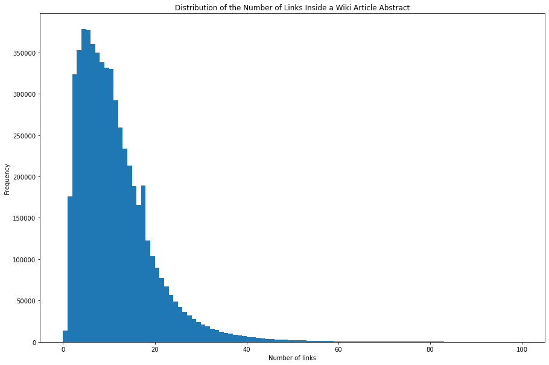

```python
#Count the number of links per article
links_count = np.array([len(df1[word]) for word in df1.index])

#Plot the histogram
plt.figure(figsize=(15,10))
plt.title('Distribution of the Number of Links Inside a Wiki Article Abstract')
plt.xlabel('Number of links')
plt.ylabel('Frequency')
plt.hist(links_count,bins=100,range=(0,100))
```

It would be also cool to know what would be the highest number of starting letters among the articles. The program will get all the starting letter of each artcile and count the top ten.

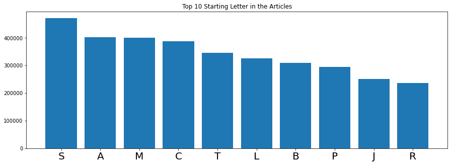

```python
index1 = list(df1.index.str[:1])
c = Counter(index1)

top_10_letter = c.most_common()[0:10]

labels, ys = zip(*top_10_letter)
xs = np.arange(len(labels))

plt.figure(figsize=(15,5))
plt.bar(xs, ys)
#Replace default x-ticks with xs, then replace xs with labels
plt.xticks(xs, labels,fontsize=20)
plt.title('Top 10 Starting Letter in the Articles')
plt.show()
```

From the results of the graph, the highest number of Starting Letter of the Artciles in Wikipedia is actually 'S'.

Another cool EDA for this data is the number of words per article. Using the program below, we can check how many spaces are there in the articles.

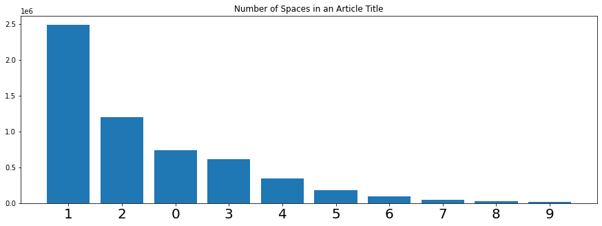

```python
index2 = list(df1.index.str.count(' '))
c1 = Counter(index2)
numberword10 = c1.most_common()[0:10]

labels, ys = zip(*numberword10)
xs = np.arange(len(labels))

plt.figure(figsize=(15,5))
plt.bar(xs, ys)
#Replace default x-ticks with xs, then replace xs with labels
plt.xticks(xs, labels,fontsize=20)
plt.title('Number of Spaces in an Article Title')
plt.show()
```

The results of the graphs shows that the highest number of spaces in the articles is 1 space. This means that the highest number of article title in wikipedia consists of 2 Words. the resuls also shows the suceeding top ten.

MODELS

The data is organized into an undirected network using the NetworkX package utilized in the function given below. The network is set so that the wikipedia pages are nodes and the edges are the links.

Additionally, the network is centered around a chosen page/node. The network is built beginning with the main page, then establishing the edges based on the links of the main page. Nodes are then established by 'following' the links to their respective pages. The process is repeated with the newly-established 1st-degree-related nodes to connect to the 2nd-degree-related nodes and edges.

Technically, this makes it so that the edges are (loosely termed) 'pseudo-directed' such that the edges are *at least* out-going edges in the priority of Main > 1st degree relative > 2nd degree relative nodes.

As an example consistent with the network shown below centered around the Asian Institute of Management page (AIM), the AIM (main) page links to the Philippines (1st d.r.) page, but the network model does not indicate if the Philippines page links back to the AIM page. The priority mentioned refers to the programming priority where all 1st d.r. links *must* be linked *from* the AIM page. Pages that link *to* the AIM page but are not linked *by* the AIM page are excluded.

This pseudo-directed network is reasonable when considered under the scope of the intended application which is to provide a suggestion feature based on the current page the user is at. The pseudo-directed edges are representative of the relevance based solely from the current page (the node that the network is centered around). In other words, the network is only concerned with where the user might land after a few clicks from the current page and suggests a relevant page within that network.

The 'relevance' of the page within the network can be determined using node centrality, to be further discussed in the results section.

```python
def net_x(main, first_deg, data):
    """ A Function that will accept an input string for the Wikipedia
    Article and add nodes and edges on the Network Plot.

    Parameters
    ----------
    main: str
        Input string or sample Wikipedia Article
            ex. 'Data Wrangling'

    first_deg: list
        Input list of First Degree from the Processed Data

    data: DataFrame
        Input Dataframe from the Processed Data containing the articles
        and wikipedia links

    Returns
    -------
    Add Edges on the Network X Library"""

    # forms the first degree connections
    G.add_edges_from([[main, i] for i in first_deg])

    # forms the second degree connection
    for i in first_deg:
        try:
            z = data[i.capitalize()]
            G.add_edges_from([i, j] for j in z)
        except:
            pass
```

This function is actually a complement function of the plotting of the Article's networks. This function will add the edges of the per article with its corresponding links and will also check if the corresponding links do also is included in the processed data which will be the 2nd degree network of the main string or article chosen.

```python
def net_x1(main, first_deg, data):
    """ A Function that will accept an input string for the Wikipedia
    Article and add Edges on the Network Plot.

    Parameters
    ----------
    main: str
        Input string or sample Wikipedia Article
            ex. 'Data Wrangling'

    first_deg: list
        Input list of First Degree from the Processed Data

    data: DataFrame
        Input Dataframe from the Processed Data containing the articles
        and wikipedia links

    Returns
    -------
    Add Edges on the Network X Library with direct connection"""

    G.add_edges_from([[main, i] for i in first_deg])
    dict2 = {}
    capt = [(i.capitalize()) for i in first_deg]
    for i in first_deg:
        if i.capitalize() in data.index:
            z = data[i.capitalize()]
            for j in z:
                dict2.update({j: i})
                if j.capitalize() in capt:
                    G.add_edge(i, j)

    for x1 in first_deg:
        if x1.capitalize() in data.index:
            m = data[x1.capitalize()]
            for x2 in m:
                if x2 in dict2 and dict2[x2] != x1:
                    G.add_edge(x1, x2)
                    G.add_edge(dict2[x2], x2)

    return dict2
```

This function is actually a complement function of the plotting of the Article's networks. This function will add the edges of the per article with its corresponding links and will check also if it has connected links in the first degree network. This function will only show all connected nodes.

FIGURES/PLOTS

```python
df1.index = df1.index.str.capitalize()
```

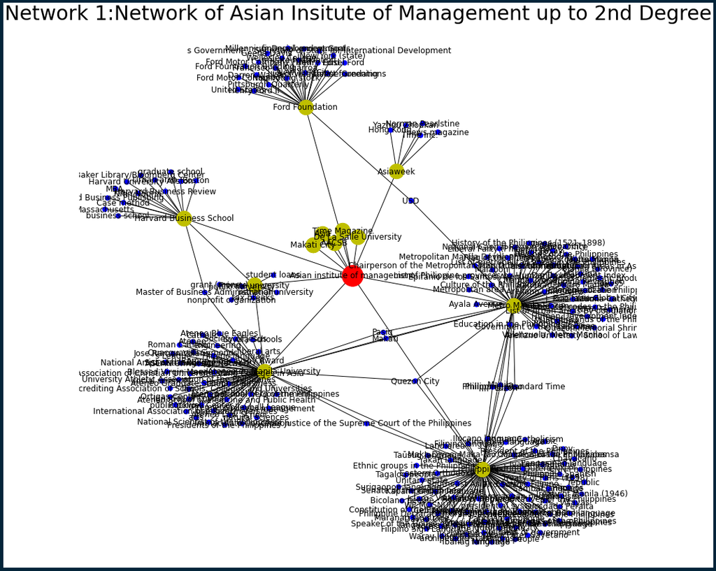

```python
fig, ax = plt.subplots(1, 1, figsize=(15,15),linewidth=10,edgecolor="#04253a")
G = nx.Graph()
string = 'Asian institute of management'
net_x(string, df1[string],df1)
pos = nx.spring_layout(G)
nx.draw(G,pos,node_color='b', node_size=50, with_labels=True)

nx.draw_networkx_nodes(G, pos, nodelist=[string], node_size=1000,
                       node_color='r')

nx.draw_networkx_nodes(G, pos, nodelist=df1[string], node_size=500,
                       node_color='y')

plt.title("Network 1:Network of Asian Insitute of Management up to"
          " 2nd Degree",
          fontsize=30)


ax.axis('off')

plt.show()
```

The network looks impressive, but is difficult to make use of. The isolated 2nd degree nodes that are connected to only 1 other node draws some centralities away from Asian Institute of Management, our main node. While we still want to keep the 2nd degree nodes in the network, we want to filter through them once more to retain only the relevant ones, which is chosen to be those with at least 1 other connection in the network

Getting Centrality Values:

```python
a = nx.closeness_centrality(G)
d = {k: v for k, v in sorted(a.items(), key=lambda item: -item[1])}
for item, rank in zip(d.items(),range(11)):
    print(f'{item[0]} - {1/item[1]}')
```

```
Philippines - 1.8227848101265822
Metro Manila - 1.9324894514767932
Asian institute of management - 1.9493670886075949
Ateneo de Manila University - 1.9493670886075949
Quezon City - 2.3755274261603376
Manila - 2.590717299578059
Philippine peso - 2.590717299578059
Philippine Standard Time - 2.590717299578059
Luzon - 2.590717299578059
Chief Justice of the Supreme Court of the Philippines - 2.5949367088607596
Private university - 2.6329113924050636
```

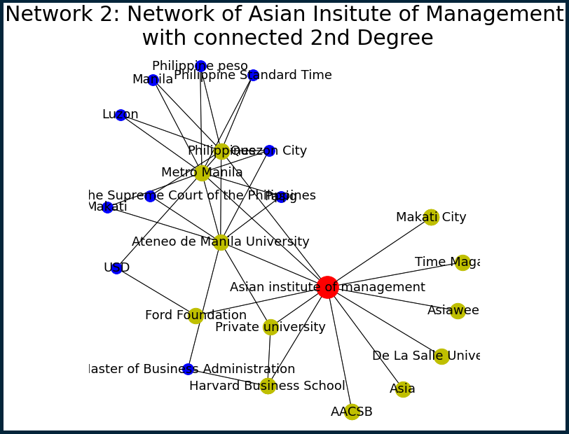

```python
fig, ax = plt.subplots(1, 1, figsize=(10,10),linewidth=10,edgecolor="#04253a")
G = nx.Graph()
string = 'Asian institute of management' #Type the main topic here
net_x1(string, df1[string],df1)
pos = nx.spring_layout(G)

nx.draw(G,pos,node_color='b', node_size=50, edge_color='black')

nx.draw_networkx_nodes(G, pos, nodelist=[string], node_size=1000,
                       node_color='r')

nx.draw_networkx_nodes(G, pos, nodelist=df1[string], node_size=500,
                       node_color='y')

nx.draw_networkx_edges(G, pos, width=1.0, alpha=0.5)

degree_2nd = G.nodes - df1[string] - {string}

nx.draw_networkx_nodes(G, pos, nodelist=degree_2nd, node_size=250,
                       node_color='b')

nx.draw_networkx_labels(G, pos , font_size=18)

plt.title("Network 2: Network of Asian Insitute of Management\n"
          " with connected 2nd Degree", fontsize=30)

ax.axis('off')

plt.show()
```

We apply the model on another page as another example. The Data wrangling page was chosen this time.

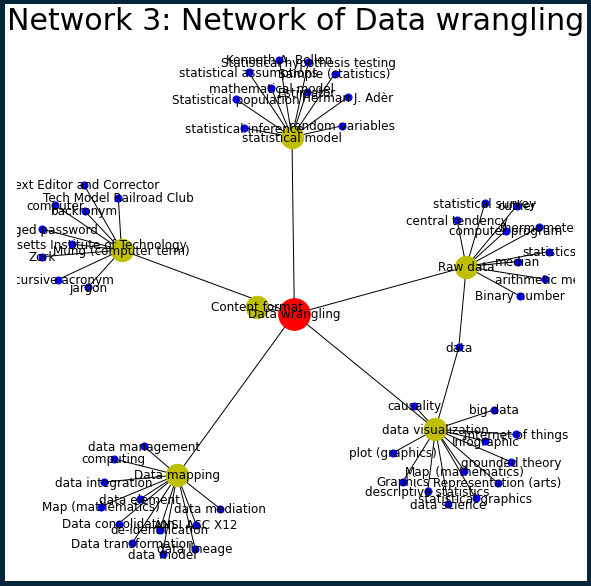

```python
fig, ax = plt.subplots(1, 1, figsize=(10,10), linewidth=10,
                       edgecolor="#04253a")
G = nx.Graph()
string = 'Data wrangling'
net_x(string, df1[string],df1)
pos = nx.spring_layout(G)
nx.draw(G,pos,node_color='b', node_size=50, with_labels=True)

nx.draw_networkx_nodes(G, pos, nodelist=[string], node_size=1000,
                       node_color='r')

nx.draw_networkx_nodes(G, pos, nodelist=df1[string], node_size=500,
                       node_color='y')

plt.title("Network 3: Network of Data wrangling", fontsize=30)

ax.axis('off')

plt.show()
```

Getting Centrality Values:

```python
a = nx.closeness_centrality(G)
d = {k: v for k, v in sorted(a.items(), key=lambda item: -item[1])}
for item, rank in zip(d.items(),range(11)):
    print(f'{item[0]} - {1/item[1]}')
```

```
Data wrangling - 1.8983050847457628
data visualization - 2.440677966101695
Data mapping - 2.4745762711864407
Raw data - 2.5423728813559325
statistical model - 2.5423728813559325
Mung (computer term) - 2.576271186440678
Content format - 2.88135593220339
data - 3.084745762711864
Graphics - 3.4237288135593222
Representation (arts) - 3.4237288135593222
Map_(mathematics) - 3.4237288135593222
```

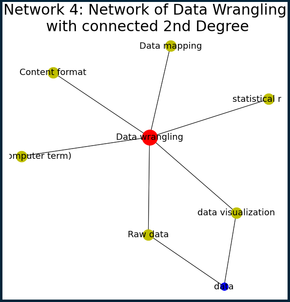

```python
fig, ax = plt.subplots(1, 1, figsize=(10,10),linewidth=10,edgecolor="#04253a")
G = nx.Graph()
string = 'Data wrangling' #Type the main topic here
net_x1(string, df1[string],df1)
pos = nx.spring_layout(G)

nx.draw(G,pos,node_color='b', node_size=50, edge_color='black')

nx.draw_networkx_nodes(G, pos, nodelist=[string], node_size=1000,
                       node_color='r')

nx.draw_networkx_nodes(G, pos, nodelist=df1[string], node_size=500,
                       node_color='y')

nx.draw_networkx_edges(G, pos, width=1.0, alpha=0.5, length=0/2)

degree_2nd = G.nodes - df1[string] - {string}

nx.draw_networkx_nodes(G, pos, nodelist=degree_2nd, node_size=250,
                       node_color='b')

nx.draw_networkx_labels(G, pos , font_size=18)

plt.title("Network 4: Network of Data Wrangling\n"
          " with connected 2nd Degree", fontsize=30)

ax.axis('off')
plt.show()
```

RESULTS AND DISCUSSION

The use of the network can be extended into the field of network science to study the connectedness of the information found in wikipedia pages. One application of this is to develop a suggestion feature to wikipedia which suggests indirectly related pages based on their centrality in a network centered around the current page, which can be interepreted as their ‘relevance’ to the content in the current page. In general, Centrality could be described as the importance of a position of a node in a graph, and hence, can be used to quantify its importance in the network [10]. There are various metrics to measure centrality, such as degree, betweeness, closeness, eigenvector, pagerank centrality and many more.

In this paper, closeness centrality was used. Closeness centrality can be defined in terms of the the distance between nodes y and x. Mathematically, this is defined as:

# $\frac {1} {\sum \limits _{y} d(y,x)}$

Computing for the closeness centrality of the AIM network, the 5 nodes with the highest values are:

1. Philippines
2. Metro Manila
3. Ateneo de Manila University
4. Quezon City
5. Manila

By getting the reciprocal of the computed centrality values, the geodesic distance of each nodes from all other nodes can be obtained. In the context of this network, this distance can be treated as the total number of clicks needed to reach all the nodes.

The network X module, however, scales the centrality values based on the fraction of reachable nodes as shown in equation 2 [12]:

### $C(x) = \frac{n - 1}{\sum_{y=1}^{n-1} d(y, x)}$

where n is the number of reachable nodes. Hence, by getting its reciprocal, the average number of clicks, and not the total sum, to reach other nodes is obtained. Based from this, Philippines has an average geodesic distance of 1.83. In other words, it takes, on average, 1.83 clicks to reach every other nodes in the network starting from the wikipedia page of Philippines. For Metro Manila, it is 1.93, Ateneo De Manila at 1.95, Quezon city at 2.4, and Manila up to Luzon tied at 2.6.

For data wrangling, the 5 most relevant concepts based on centrality are:

1. Data visualization
2. Data mapping
3. Raw data
4. statistical model
5. Mung (computer term)

Using the same approach done with the AIM network, it takes 2.44 clicks to reach all nodes starting from data visualization, 2.47 for data mapping, 2.54 for raw data and statistical model, and 2.58 for Mung.

The "pseudo-directed" networks formed from wikipedia article abstracts and links form a basic knowledge representation of a subject, and can be considered a semantic network. These semantic networks can be used to develop a suggestion feature for wikipedia based on how influential a topic is to the entire network.

References and Acknowledgments

[1] https://pandas.pydata.org/pandas-docs/stable/reference/api/pandas.DataFrame.isnull.html

[2] https://en.wikipedia.org/wiki/Wikipedia:Database_download

[3]https://networkx.github.io/documentation/networkx-1.10/index.html

[4]https://python-graph-gallery.com/326-background-colour-of-network-chart/

[5]https://learnui.design/tools/data-color-picker.html#single

[6] https://brohrer.github.io/matplotlib_framing.html

[7] http://mu.netsoc.ie/wiki/

[8] Final Technical Report of Learning Team 1(Rappler Topic) (Esclanda,Esleta,Robles,Silva)

[9] https://www.sciencedirect.com/topics/computer-science/semantic-network

[10]. Cˇerba O, et.al. "Centrality as a Method for the Evaluation of Semantic Resources for Disaster Risk Reduction." International Journal of Geo-Information. (2017)

[11]. Bhasin J. "Graph Analytics — Introduction and Concepts of Centrality". Medium. (2019). https://towardsdatascience.com/graph-analytics-introduction-and-concepts-of-centrality-8f5543b55de3

[12]. https://networkx.github.io/documentation/networkx-1.10/reference/generated/networkx.algorithms.centrality.closeness_centrality.html